# Relationships between quantitative variables

Matthew Rudd  
3/2/21

### Motivation

- Data is often **multivariate** ; we want to know how the variables relate. Variables can be **quantitative** and/or **categorical**.
- For two quantitative variables, the basic tools are **scatterplots**, **correlation**, and **linear regression**.

### Scatterplots

As always, start by **plotting the data**!

- **Scatterplots** graph two quantitative variables simultaneously..
- Each point in a scatterplot corresponds to one observation.
- Look for an overall pattern. Is there a **positive association**, a **negative association**, or **no association** ?

### Example

Heights of mothers and daughters:

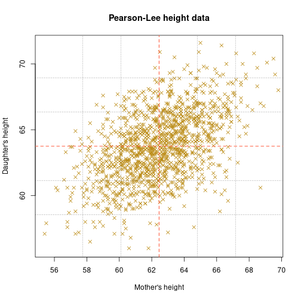

### More informative scatterplots

Scatterplots can also provide categorical information:

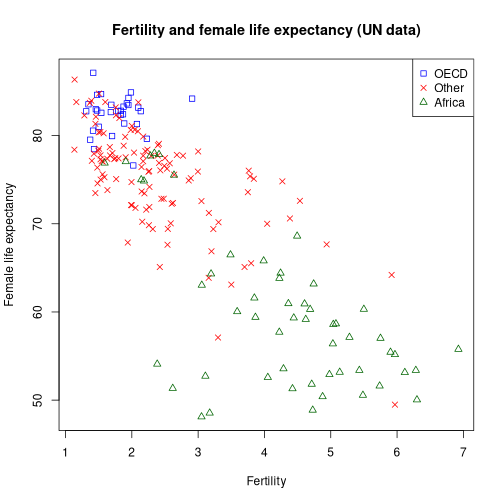

### Interpreting correlations

- Positive correlation corresponds to a positive association; negative correlation corresponds to a negative association.
- If *r* is close to 0, the linear relationship is weak; this relationship is stronger when *r* is closer to 1 or -1.
- *r* = 1 and *r* = -1 correspond to **perfect** linear relationships. **Never happens!**

### Anscombe's quartet

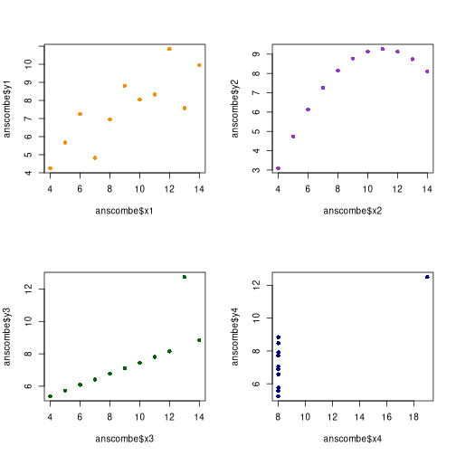

*r* is about 0.8 for all 4 data sets.

*r* is only useful for one of these. (?)

### Mothers and daughters

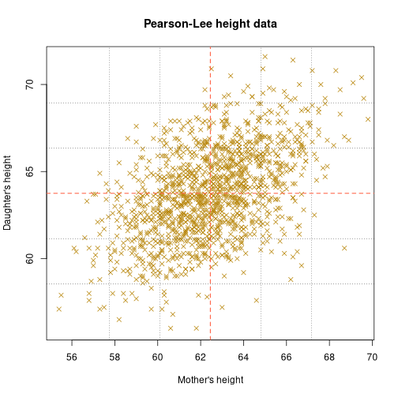

Mothers' average height: 62.45"

Mothers' SD: 2.36"

Daughters' average height: 63.75"

Daughters' SD: 2.6"

Correlation: 0.49

### Short mothers

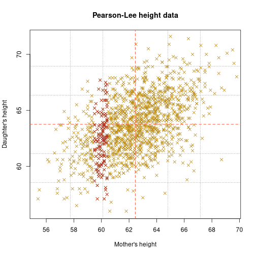

Dark red points:

5' mothers

Best guess of daughter's height?

### Short mothers

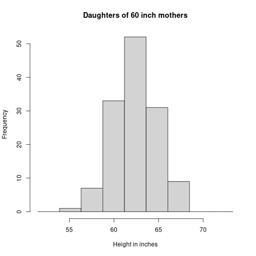

Daughters' heights follow normal curve

**Average: 62.4"**

SD: 2.43"

**Average height above 60"**

### Short mothers

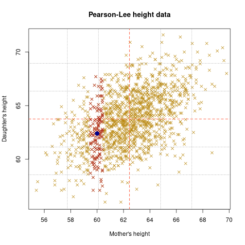

Dark blue point:

(60, 62.4)

**On the average**, a 5' mother's daughter is 62.4 inches tall.

### Short mothers

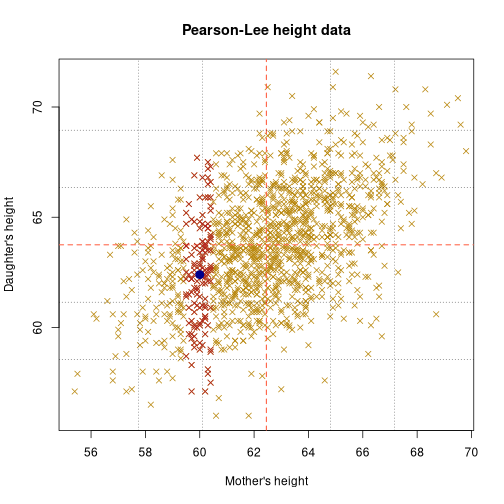

5' mother :

z = -1.04

Best guess of 62.4 :

z = -0.52

**Compare the product of r and mom's z: -0.51**

### Tall mothers

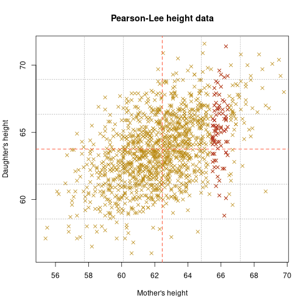

Dark red points:

5'6" mothers

Best guess of daughter's height?

### Tall mothers

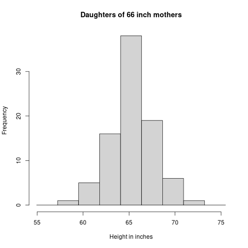

Daughters' heights follow normal curve

**Average: 65.22"**

SD: 2.28"

**Average height below 66"**

### Tall mothers

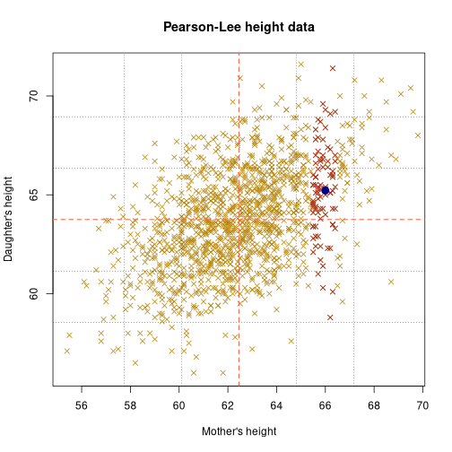

Dark blue point:

(66, 65.22)

**On the average**, a 5'6" mother's daughter is 65.22 inches tall.

### Tall mothers

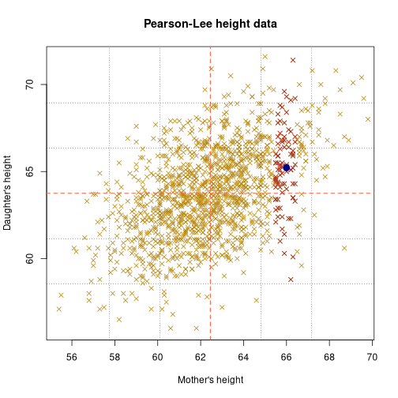

5'6" mother :

z = 1.51

Best guess of 65.22 :

z = 0.56

**Compare the product of r and mom's z: 0.74**

### Mothers and average daughters

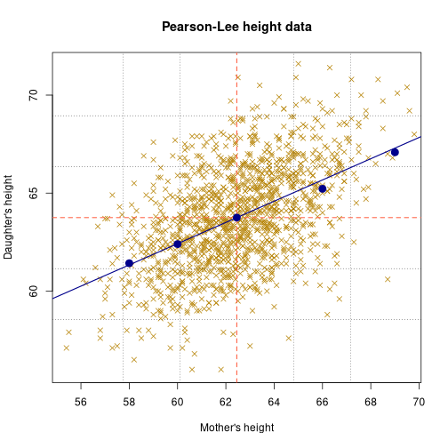

This process yields points that roughly follow a line.

**This is the *regression line*.**

The regression line always goes through the **point of averages**.

### Mothers and average daughters

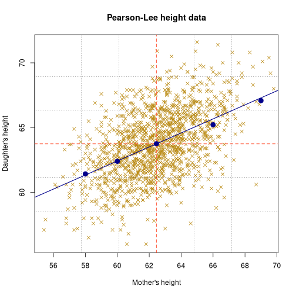

To follow the **regression line**:

When mom's height changes by 1 SD, the daughter's **predicted** average height changes by r SDs.

Remember which SD is which!

### Linear regression

If there is a linear relationship, what line best fits the data?

- “Best fit” : **The sum of the squares of the residuals is as small as possible.**
- **Residuals** are the differences between the real data and the predictions on the line.
- The **line of best fit** is the **regression line**.

### Caveats

- Correlation and linear regression **assume** a linear relationship; otherwise, don't use them!
- Watch out for **influential observations** and **lurking variables**.
- The regression line can be useful for **prediction** but not for **extrapolation**.

> **CORRELATION IS NOT CAUSATION!**